# DATA 608 FINAL - VISUALIZATIONS OF THE HOMELESS EPIDEMIC

Alejandro D. Osborne

May 15, 2019

## Introduction

Homeless people are one of the most vulnerable and marginalized members of society in the United States of America. According to the McKinney -Vento Homeless Assistance Act of 1987, a person is experiencing a homelessness condition whenever she or he is lacking a regular and adequate nighttime residence. It is a particularly harmful state, especially considering that it is usually associated with a variety of other problems in health, education or employment. In the USA, during 2018 there were 552,830 people living in homeless condition.

This portfolio aims to visualize, and hence be able to dimension, the homelessness situation in the USA, in the hope of providing useful information and insights to understand this social phenomenon. Visualizations will consider the number of people in homeless situation (and different homelessness classification) across the different states of the country. In addition, the goal is to provide visual information of other data which may be interesting and possibly associated to this problem, such as resources assigned to emergency housing programs, GDP per state, performance indicators of shelters, etc. The main source of information will be the U.S. Department of Housing and Urban Development (HUD).

We will be mainly using tidyverse library for data manipulation, ggplot2 for visualizations, Simple Features for mapping.

## Homelessness in time

A first necessary approach is to quantify the amount of people experiencing homelessness through time. We would like to know if the total amount of homeless has increased, decreased or kept constant during last decade. Same question would be interesting for evolution of sub populations of homeless such as: sheltered and unsheltered, those living in families or alone, etc.

Generally speaking, the total homeless population has had a constant decrease for the last decade. We can observe that from 2012 to 2013 there was a steeper decline. From 2016 to 2018 there has been a slight increase. In addition, the unsheltered population has proportionally decreased more than the sheltered population.

[output not shown]

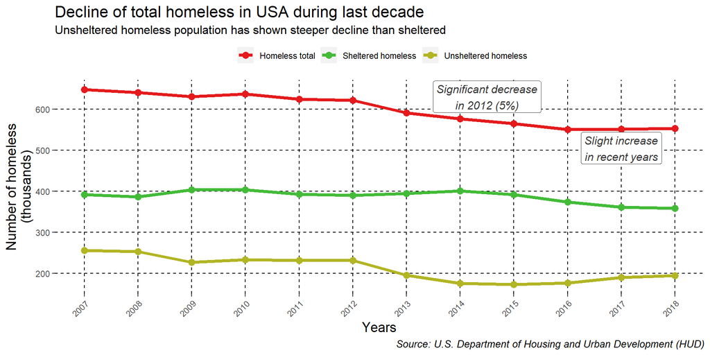

## Homeless Demographics

Through this section we present several demographics of the homeless population.

Thanks to the data, we can understand the following:

*For most people, homelessness is a temporary rather than a chronic experience.* A significant proportion are individuals alone rather than in families. * Although men are a majority and are more visible, there is still a significant proportion of women. * Most people experiencing homelessness are in an sheltered condition.

[output not shown]

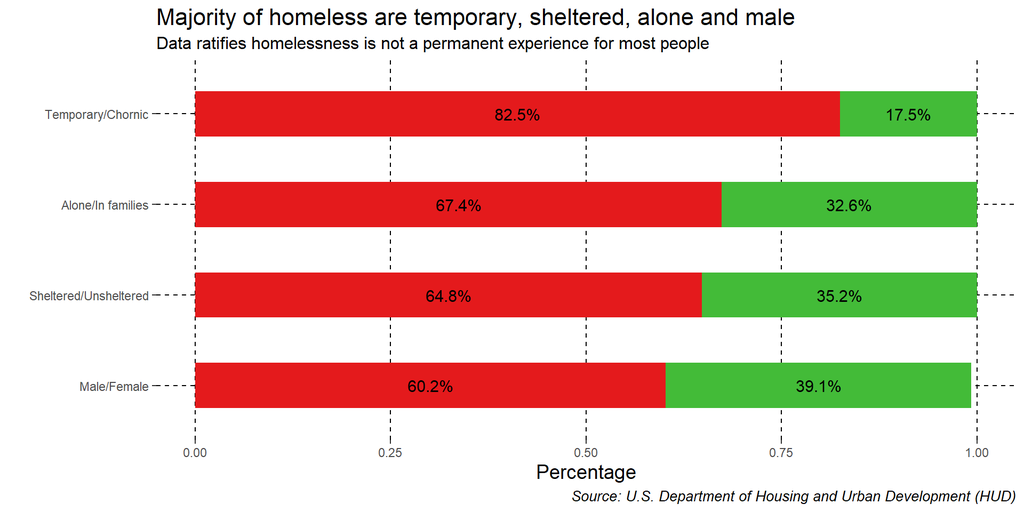

Race is a significant element of homeless demographics. Notably, we can observe that the different races present in the US population are not present in the homeless populations in the same proportions.

[output not shown]

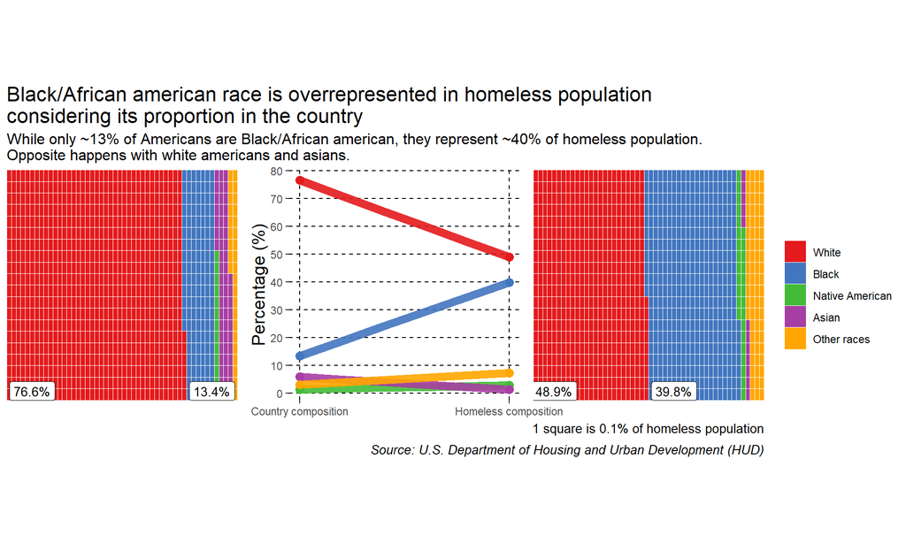

## Homelessness in different states during 2018

We will now compare the amount of homeless between states. NY and HI present severe rates of homeless per capita.

[output not shown]

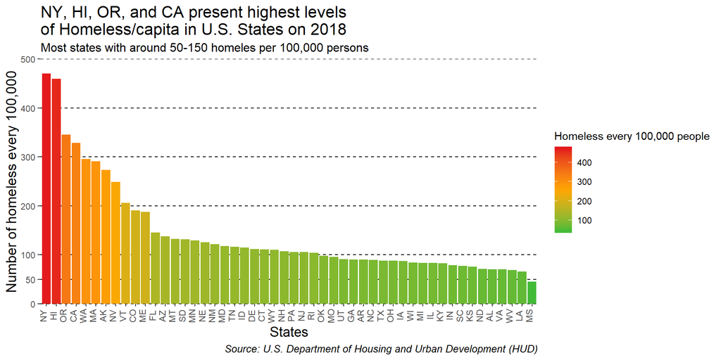

It would now be interesting to have a geographical perspective of the differences between the states

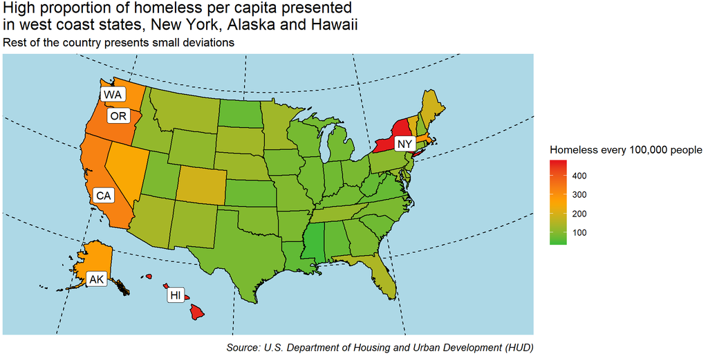

## Homelessness and GDP

[output not shown]

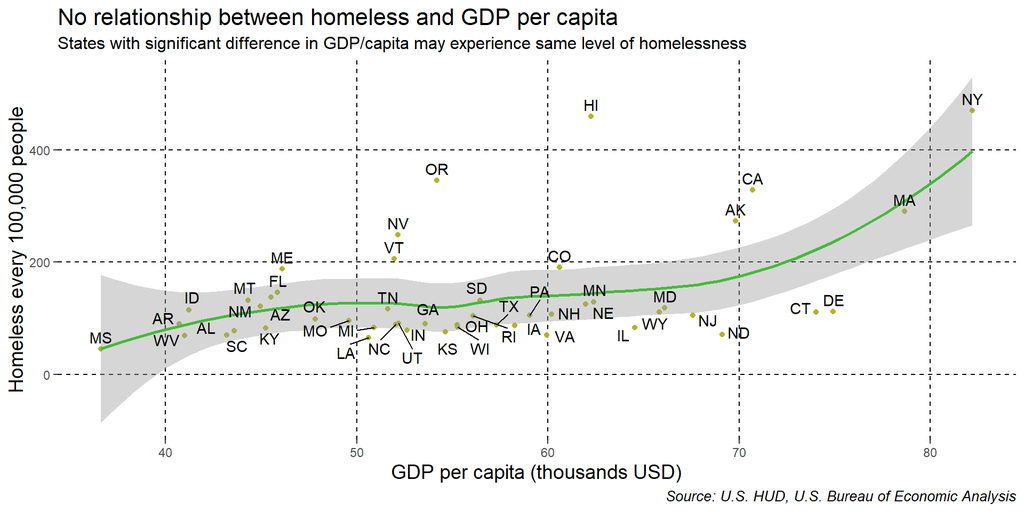

## Homelessness and Resources

The Department of Housing and Urban development of the US assigns funding to the different states to support programs aiming to build home for all their citizens. Among these programs there is the The Continuum of Care (CoC) Program, designed to promote community wide commitment to the goal of ending homelessness.

In the following graph we will study amount of homeless in states and their allocation of resources for CoC program. As we would have expected, states with big amount of homeless receive more allocations.

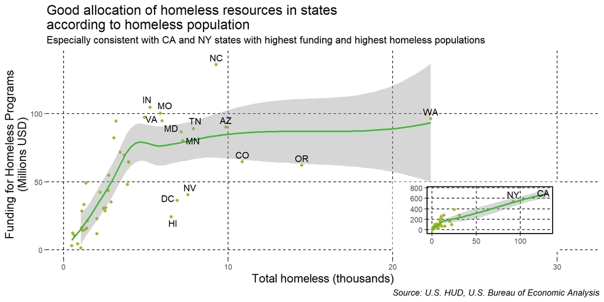

## Studying New York City Homeless Population

As we have shown, New York State presents the highest index of homeless people per capita in the USA. Here we will present some brief more information about the homeless situation in the states capital city.

We are interested in the distribution of unsheltered homeless through different areas en New York. In addition, we would like to know the location of the different drop-in Centers, where homeless people are provided with hot meals, showers, medical help and a place to sleep, as well as locations of Homebase (Homeless Prevention Network) offices.

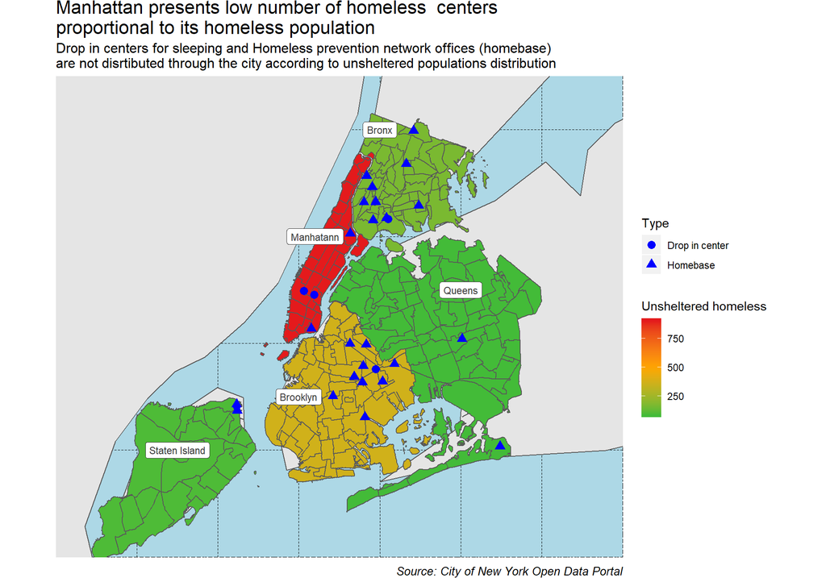